# final data assignment

caroline wishner

9/22/2020

## Introduction

I was given a dataset based on a study on humans exploring a connection between height, weight and other variables with hypertension. Hypertension, also known as high blood pressure, is condition in which the force of the blood against the artery walls is too high. It is very common with over 3 million US cases per year. Hypertension is usually defined as blood pressure above 140/90, and is considered severe if the pressure is above 180/120. While high blood pressure often has no symptoms, if untreated, it can cause health conditions overtime, such as heart disease and stroke. This paper aims to derive any correlation from the presented data.

## Specific Aims

1. Utilize the data in order to find some correlation between the variables"
2. Identify and validate the most relevant prediction tool(s) for predicting the risk of developing Hypertension"

## Data Representation/Descriptive Stats

"The dataset has the following variables and this is what they mean:

id: Person Identifier

age: Age of the subject

gender: Gender of the subject

height: Height in centimeters

weight: Weight in kilograms

bmi: The calculated body mass index

systolic: Systolic BP at the time of measurement

diastolic: Diastolic BP at the time of measurement

```r
summary(caroline.dataset)
```

```
##        id             age           gender              height
##  Min.   :  1.0   Min.   :12.00   Length:500         Min.   :137.6
##  1st Qu.:125.8   1st Qu.:24.00   Class :character   1st Qu.:154.1
##  Median :250.5   Median :34.00   Mode  :character   Median :160.5
##  Mean   :250.5   Mean   :34.82                      Mean   :161.0
##  3rd Qu.:375.2   3rd Qu.:45.00                      3rd Qu.:167.1
##  Max.   :500.0   Max.   :66.00                      Max.   :189.5
##      weight            bmi           systolic       diastolic
##  Min.   : 49.39   Min.   :16.89   Min.   : 91.0   Min.   : 41.00
##  1st Qu.: 77.76   1st Qu.:28.78   1st Qu.:130.0   1st Qu.: 73.00
##  Median : 84.54   Median :33.09   Median :150.0   Median : 84.00
##  Mean   : 85.05   Mean   :33.29   Mean   :149.8   Mean   : 84.23
##  3rd Qu.: 92.22   3rd Qu.:37.12   3rd Qu.:170.0   3rd Qu.: 95.00
##  Max.   :123.45   Max.   :56.75   Max.   :209.0   Max.   :128.00
```

Write up of descriptive statistics of the major variables with a models relating BMI with systolic BP and a model relating BMI with diastolic BP."

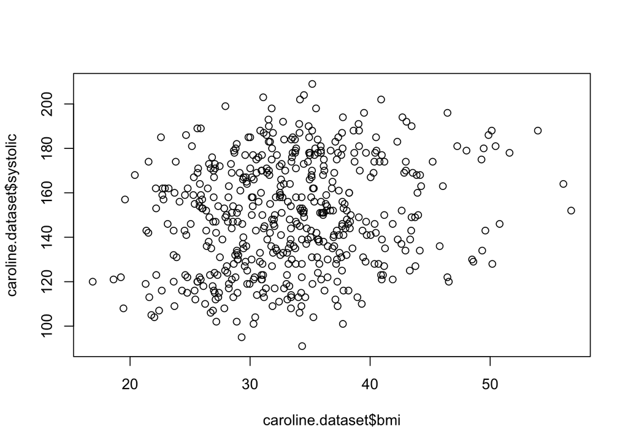

```r
plot(caroline.dataset$bmi, caroline.dataset$systolic)
```

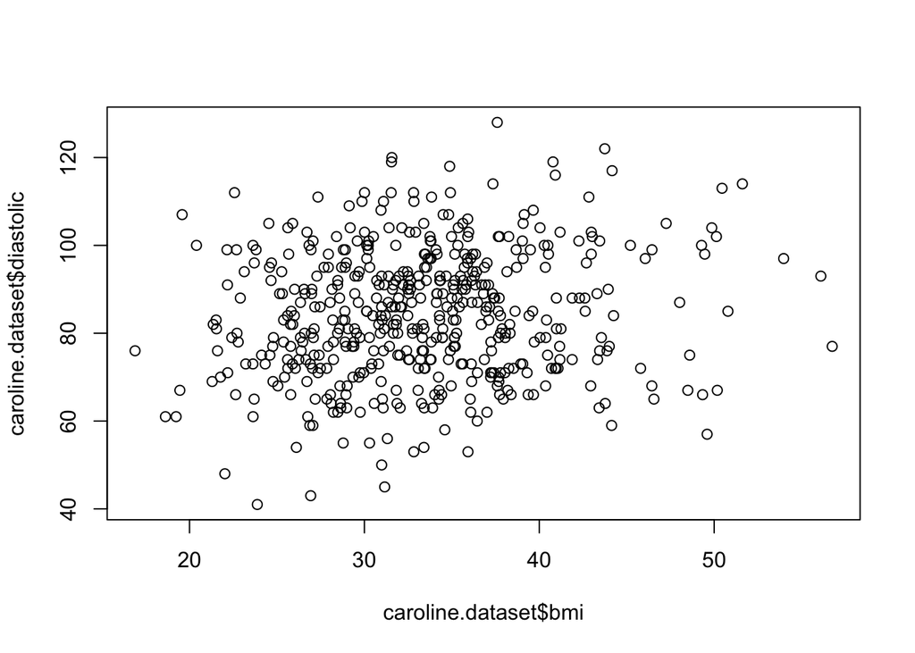

```r
plot(caroline.dataset$bmi, caroline.dataset$diastolic)
```

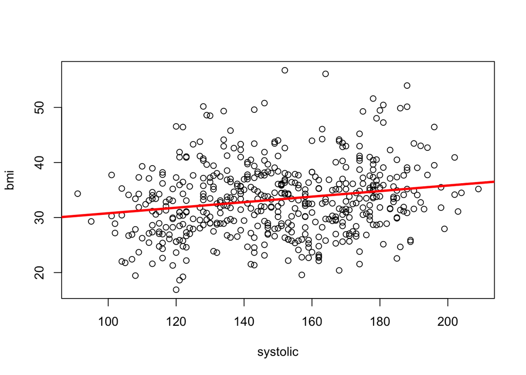

```r
plot(bmi ~ systolic, data=caroline.dataset)

regrline <- lm(bmi ~ systolic, data=caroline.dataset)

abline(regrline, lwd=3, col='red')
```

```r
summary (regrline)
```

```
##
## Call:
## lm(formula = bmi ~ systolic, data = caroline.dataset)
##
## Residuals:
##      Min       1Q   Median       3Q      Max
## -14.8998  -4.3587  -0.4982   3.8728  23.3488
##
## Coefficients:
##             Estimate Std. Error t value Pr(>|t|)
## (Intercept) 25.73059    1.76044   14.62  < 2e-16 ***
## systolic     0.05046    0.01160    4.35 1.65e-05 ***
## ---
## Signif. codes:  0 '***' 0.001 '**' 0.01 '*' 0.05 '.' 0.1 ' ' 1
##
## Residual standard error: 6.379 on 498 degrees of freedom
## Multiple R-squared:  0.03661,    Adjusted R-squared:  0.03468
## F-statistic: 18.93 on 1 and 498 DF,  p-value: 1.649e-05
```

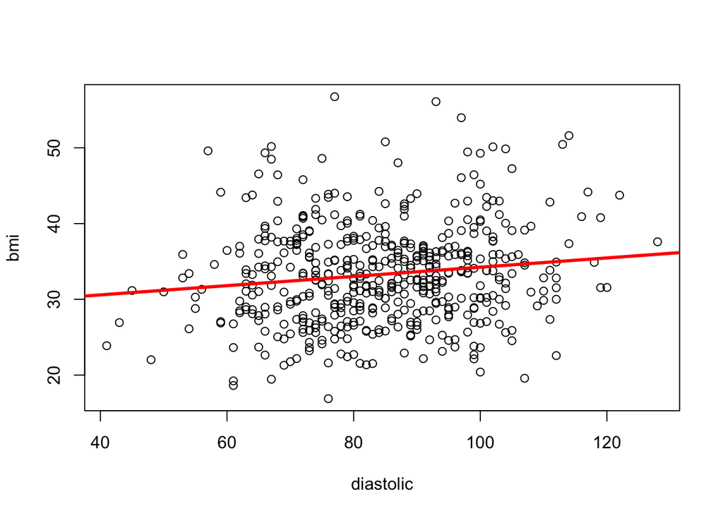

```r
plot(bmi ~ diastolic, caroline.dataset)

regrline <- lm(bmi ~ diastolic, caroline.dataset)

abline(regrline, lwd=3, col='red')
```

```r
summary (regrline)
```

```
##
## Call:
## lm(formula = bmi ~ diastolic, data = caroline.dataset)
##
## Residuals:
##      Min       1Q   Median       3Q      Max
## -15.8990  -4.4375  -0.3597   3.8817  23.9032
##
## Coefficients:
##             Estimate Std. Error t value Pr(>|t|)
## (Intercept) 28.14107    1.69151  16.637  < 2e-16 ***
## diastolic    0.06110    0.01979   3.088  0.00213 **
## ---
## Signif. codes:  0 '***' 0.001 '**' 0.01 '*' 0.05 '.' 0.1 ' ' 1
##
## Residual standard error: 6.438 on 498 degrees of freedom
## Multiple R-squared:  0.01879,    Adjusted R-squared:  0.01682
## F-statistic: 9.535 on 1 and 498 DF,  p-value: 0.002128
```